# Customer Segmentation Analysis

Paresh Gupta

Importing packages and setting the directories

```r
library(lubridate)
library(data.table) #convert seconds to days
```

```r
library(plotly) #interactive plots
library(moments) #to get skewness
library(factoextra) #to visualize clusters
library(plyr)
library(svMisc)
library(car) #3d plots
getwd()
```

```
## [1] "C:/Users/pares/OneDrive/Documents/assessments/online retail"
```

```r
setwd("C:/Users/pares/OneDrive/Documents/assessments/online retail")
```

Importing data

```r
data <- read.csv("OnlineRetail.csv",stringsAsFactors = FALSE)
str(data)
```

```
## 'data.frame':    541909 obs. of  8 variables:
##  $ InvoiceNo  : chr  "536365" "536365" "536365" "536365" ...
##  $ StockCode  : chr  "85123A" "71053" "84406B" "84029G" ...
##  $ Description: chr  "WHITE HANGING HEART T-LIGHT HOLDER" "WHITE METAL LANTERN" "CREAM CUPID HEARTS COAT HANGER" "KNITTED UNION FLAG HOT WATER BOTTLE" ...
##  $ Quantity   : int  6 6 8 6 6 2 6 6 6 32 ...
##  $ InvoiceDate: chr  "12/1/2010 8:26" "12/1/2010 8:26" "12/1/2010 8:26" "12/1/2010 8:26" ...
##  $ UnitPrice  : num  2.55 3.39 2.75 3.39 3.39 7.65 4.25 1.85 1.85 1.69 ...
##  $ CustomerID : int  17850 17850 17850 17850 17850 17850 17850 17850 17850 13047 ...
##  $ Country    : chr  "United Kingdom" "United Kingdom" "United Kingdom" "United Kingdom" ...
```

We have 541,909 rows. Here, every row belongs to a separate product bought per invoice. This means, if customer bought 3 items in a single invoice, the data will have 3 separate rows for the particular invoice.

We need to correct data types for invoice-date. InvoiceNo is a string (It includes cancelled invoices starting with “C”)

```r
#Converting invoice date to date type
data$InvoiceDate <- strptime(data$InvoiceDate, format = "%m/%d/%Y %H:%M")
summary(data)
```

```
##   InvoiceNo          StockCode         Description
##  Length:541909      Length:541909      Length:541909
##  Class :character   Class :character   Class :character
##  Mode  :character   Mode  :character   Mode  :character
##
##
##
##
##     Quantity          InvoiceDate                    UnitPrice
##  Min.   :-80995.00   Min.   :2010-12-01 08:26:00   Min.   :-11062.06
##  1st Qu.:     1.00   1st Qu.:2011-03-28 11:34:00   1st Qu.:     1.25
##  Median :     3.00   Median :2011-07-19 17:17:00   Median :     2.08
##  Mean   :     9.55   Mean   :2011-07-04 13:59:07   Mean   :     4.61
##  3rd Qu.:    10.00   3rd Qu.:2011-10-19 11:27:00   3rd Qu.:     4.13
##  Max.   : 80995.00   Max.   :2011-12-09 12:50:00   Max.   : 38970.00
##
##    CustomerID       Country
##  Min.   :12346    Length:541909
##  1st Qu.:13953    Class :character
##  Median :15152    Mode  :character
##  Mean   :15288
##  3rd Qu.:16791
##  Max.   :18287
##  NA's   :135080
```

# Observations about the data…

1. A lot of customer IDs are missing – as we cant segment non existing customers – we can remove them from dataset
2. There are negative values in quantity!
3. We have negative unit price for few products. Something is wrong here.
4. The data is from a time range of 1st December, 2010 to 9th December,2011. A little above one year.

Before removing non-existent customers, lets look at negative values in quantity and unit-price.

- Negative Quantity values?

```r
sum(data$Quantity < 0)
```

```
## [1] 10624
```

10,624 entries have negative values of quantity

```r
head(data[data$Quantity < 0,])
```

```
##     InvoiceNo StockCode                       Description Quantity
## 142   C536379         D                          Discount       -1
## 155   C536383    35004C   SET OF 3 COLOURED  FLYING DUCKS       -1
## 236   C536391     22556    PLASTERS IN TIN CIRCUS PARADE       -12
## 237   C536391     21984  PACK OF 12 PINK PAISLEY TISSUES       -24
## 238   C536391     21983  PACK OF 12 BLUE PAISLEY TISSUES       -24
## 239   C536391     21980 PACK OF 12 RED RETROSPOT TISSUES       -24
##             InvoiceDate UnitPrice CustomerID        Country
## 142 2010-12-01 09:41:00     27.50      14527 United Kingdom
## 155 2010-12-01 09:49:00      4.65      15311 United Kingdom
## 236 2010-12-01 10:24:00      1.65      17548 United Kingdom
## 237 2010-12-01 10:24:00      0.29      17548 United Kingdom
## 238 2010-12-01 10:24:00      0.29      17548 United Kingdom
## 239 2010-12-01 10:24:00      0.29      17548 United Kingdom
```

Oh. This could be the cancelled items (InvoiceNo starting with “C”)! — When the customer is returning the item, quantity is subtracted.

We need a column to separate cancelled invoices from purchases.

```r
#Creating a column that separates the purchased items vs the returned items!
data$purchased_item <- ifelse(grepl("C",data$InvoiceNo, fixed = TRUE) == TRUE, 0,1)
```

Is this the case with unit price too?

```r
subset(data,data$UnitPrice < 0)
```

```
##        InvoiceNo StockCode     Description Quantity         InvoiceDate
## 299984   A563186         B Adjust bad debt        1 2011-08-12 14:51:00
## 299985   A563187         B Adjust bad debt        1 2011-08-12 14:52:00
##        UnitPrice CustomerID        Country purchased_item
## 299984 -11062.06         NA United Kingdom              1
## 299985 -11062.06         NA United Kingdom              1
```

Bad debt is adjusted. These transactions were made by the operator to adjust money issues. Since, there is no customer involved here, eliminating this would not do any harm to us.

```r
#Removing non-existent customer IDs
data <- na.omit(data)
```

How many customers are there in total?

```r
length(unique(data$CustomerID))
```

```
## [1] 4372
```

```r
length(unique(data$InvoiceNo))
```

```
## [1] 22190
```

# 4,300 odd customers have made approx. 22,000 purchases in the given year.

Lets, look at our only categorical variable - country.

```r
sort(table(data$Country))
```

```
##
##         Saudi Arabia              Bahrain       Czech Republic
##                   10                   17                   30
##               Brazil            Lithuania              Lebanon
##                   32                   35                   45
##                  RSA   European Community United Arab Emirates
##                   58                   61                   68
##                Malta               Greece               Canada
##                  127                  146                  151
##              Iceland            Singapore          Unspecified
##                  182                  229                  244
##               Israel                  USA               Poland
##                  250                  291                  341
##                Japan              Denmark              Austria
##                  358                  389                  401
##               Sweden               Cyprus              Finland
##                  462                  622                  695
##      Channel Islands                Italy               Norway
##                  758                  803                 1086
##            Australia             Portugal          Switzerland
##                 1259                 1480                 1877
##              Belgium          Netherlands                Spain
##                 2069                 2371                 2533
##                 EIRE               France              Germany
##                 7485                 8491                 9495
##       United Kingdom
##               361878
```

Our customers come from a variety of countries. UK having the most transactions. There are researches done that show, purchasing behaviour and customers vary from different geographical locations. It would be wise, to consider similar customers and group them accordingly.

# Lets limit the data and consider only transactions coming from UK.

```r
data <- subset(data,data$Country == "United Kingdom")
```

How many customers are we dealing with now?

```r
cat("We have",length(unique(data$CustomerID)),"customers and a total of",length(unique(data$InvoiceNo)),"different invoices")
```

```
## We have 3950 customers and a total of 19857 different invoices
```

We can now create our RFM metrics, but we need to consider cancelled orders to calculate recency and frequency variables.

#———————–LETS RFM————————-

#Calculate 3 different scores for each customer #1. RECENCY – How recently has the customer made his/her purchase? #2. FREQUENCY – How frequent is the customer? How many purchases over the given time frame? #3. MONETARY VALUE – How much amount does each customer bring in?

```r
#Creating a new dataframe
customers <- as.data.frame(unique(data$CustomerID))
colnames(customers) <- "CustomerID"
```

#————RECENCY——————–

```r
data$recency <- (max(data$InvoiceDate) + days(1)) - data$InvoiceDate
data$recency <- as.numeric(data$recency)
#Now this is in seconds, lets convert it in number of days...
#data$recency <- seconds_to_period(data$recency)
#data$recency <- data$recency@day + data$recency@hour/24 + data$recency@minute/(24*60) + data$recency@.Data/(24*60*60)

#Considering only the purchases made
temp <- subset(data, data$purchased_item == 1)

recency <- aggregate(recency ~ CustomerID, data = temp, FUN = min, na.rm = TRUE)

customers <- merge(customers, recency, all = TRUE)

remove(recency)
```

#————FREQUENCY——————

```r
freq <- aggregate(InvoiceNo ~ CustomerID, data = temp, FUN = uniqueN)
customers <- merge(customers,freq, all = TRUE, by = "CustomerID")
colnames(customers)[3]  <- "Frequency"

remove(freq)
```

#———-MONETARY VALUE—————

```r
data$revenue <- data$Quantity * data$UnitPrice

revenue <- aggregate(revenue ~ CustomerID, data = data, FUN = sum)
customers <- merge(customers,revenue, all = TRUE)
remove(revenue)

summary(customers)
```

```
##    CustomerID       recency         Frequency          revenue
##  Min.   :12346   Min.   :  1.00   Min.   :  1.000   Min.   : -4287.6
##  1st Qu.:14208   1st Qu.: 18.06   1st Qu.:  1.000   1st Qu.:   282.2
##  Median :15572   Median : 51.08   Median :  2.000   Median :   627.1
##  Mean   :15562   Mean   : 92.73   Mean   :  4.246   Mean   :  1713.4
##  3rd Qu.:16914   3rd Qu.:143.09   3rd Qu.:  5.000   3rd Qu.:  1521.8
##  Max.   :18287   Max.   :374.12   Max.   :210.000   Max.   :256438.5
##                  NA's   :29       NA's   :29
```

We have 29 customers where we have NA values. These are the customers who have cancelled orders in our original data, but their purchased orders are not present. Therefore, we will not not consider these customers and remove them.

```r
customers <- na.omit(customers)
summary(customers)
```

```
##    CustomerID       recency         Frequency          revenue
##  Min.   :12346   Min.   :  1.00   Min.   :  1.000   Min.   : -1165.3
##  1st Qu.:14208   1st Qu.: 18.06   1st Qu.:  1.000   1st Qu.:   289.8
##  Median :15569   Median : 51.08   Median :  2.000   Median :   633.7
##  Mean   :15561   Mean   : 92.73   Mean   :  4.246   Mean   :  1728.4
##  3rd Qu.:16913   3rd Qu.:143.09   3rd Qu.:  5.000   3rd Qu.:  1530.8
##  Max.   :18287   Max.   :374.12   Max.   :210.000   Max.   :256438.5
```

#Observations…

There are negative values of revenue – probably customers who purchased something before the time frame given, but returned it in the given timeframe! Setting these values to zero!

```r
customers$revenue[customers$revenue < 0] <- 0
```

This looks much better now.

```r
sum(customers$recency == 0)
```

```
## [1] 0
```

#—————-PRE-PROCESSING DATA ———————

### Lets look at outliers now.

Before, evaluating outliers, lets do a pareto analysis to understand how outliers can be a crucial factor here.

#———–The 80/20 rule / Pareto Analysis————

– Pareto Analysis – The rule says that more or less, 80% of the results come from the 20% of the causes! In this context, around 80% of sales should be caused by 20% of the customers. Meaning, top 20% customers contribute most to the sales – these would be are our high value customers! Lets see if this is true here.

```r
pareto_cutoff <- 0.8*sum(customers$revenue)

customers <- customers[order(customers$revenue, decreasing = TRUE),]

customers$pareto <- ifelse(cumsum(customers$revenue) <= pareto_cutoff,"Top 20%","Bottom 80%")
customers$pareto <- as.factor(customers$pareto)

round(prop.table(table(customers$pareto)),2)
```

```
##
## Bottom 80%    Top 20%
##       0.71       0.29
```

```r
customers <- customers[order(customers$revenue),]

# Lets look at it visually!

p1 <- ggplot(data = customers) +
  geom_point(aes(x = Frequency,y = revenue, color = recency, shape = pareto)) + ggtitle("Original Values") + scale_shape_manual(name = "80/20 rule",values = c(3,8)) + theme(legend.position = "top")

ggplotly(p1)
```

```
## PhantomJS not found. You can install it with webshot::install_phantomjs(). If it is installed, please make sure the phantomjs executable can be found via the PATH variable.
```

[interactive chart not shown]

This map is very hard to read. Almost all the bottom 80% of customers are grouped together in lower corner. We need to evaluate RFM variables for skewness and deal accordingly.

#——How skewed is out data?———

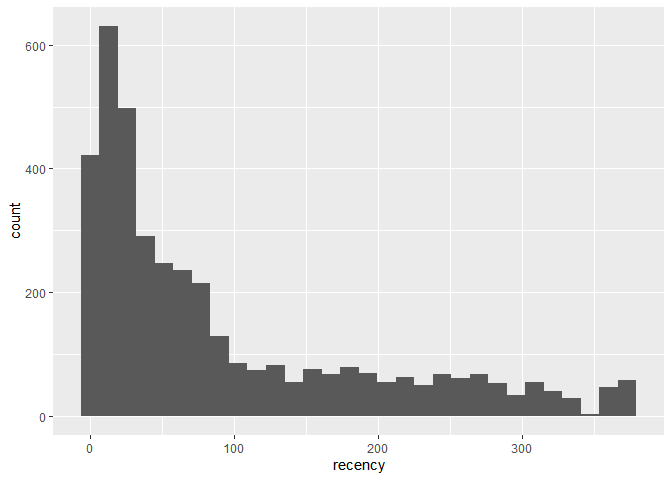

```r
ggplot(data = customers, aes(x = recency)) +
  geom_histogram()
```

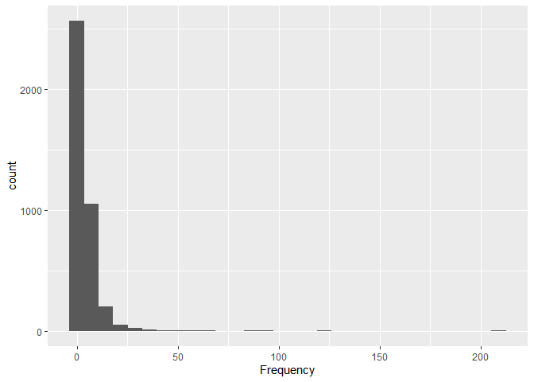

```r
ggplot(data = customers, aes(x = Frequency)) +
  geom_histogram()
```

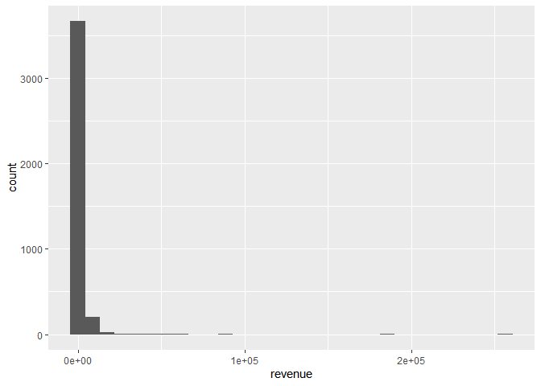

```r
ggplot(data = customers, aes(x = revenue)) +
  geom_histogram()
```

Lets, also look at mathematically

```r
skewness(customers$recency)
```

```
## [1] 1.244409
```

```r
skewness(customers$Frequency)
```

```
## [1] 10.80211
```

```r
skewness(customers$revenue)
```

```
## [1] 23.27612
```

All the variables are positively skewed! Lets take log tranform of each! And, We need to tranform the data (scale and normalize it!)

```r
customers$log_recency <- log(customers$recency)
customers$log_frequency <- log(customers$Frequency)

customers$revenue <- customers$revenue + 0.01 #Since, there are 0 values, we dont wanna take log(0)
customers$log_revenue <- log(customers$revenue)

#Lets scale the data using Z- scores!

customers$z_recency <-  scale(customers$log_recency, scale = TRUE, center = TRUE)
customers$z_frequency <-  scale(customers$log_frequency, scale = TRUE, center = TRUE)
customers$z_revenue <- scale(customers$log_revenue, scale = TRUE, center = TRUE)
```

Lets look at the result now!

```r
#Visualizing the log transformed and scaled variables!

p2 <- ggplot(data = customers) +
  geom_point(aes(x = log_frequency,y = log_revenue, color = log_recency, shape = pareto)) + ggtitle("Log Tranformed values") + scale_shape_manual(name = "80/20 rule",values = c(3,8))

ggplotly(p2)
```

[interactive chart not shown]

#Top Right Corner – has quite a few outliers – these are our high frequency; high revenue; and fairly recent customers – #Bottom Left Corner – these are outliers too – with low frequency; revenue

Lets see the results for scaled variables too.

```r
p3 <- ggplot(data = customers) +
  geom_point(aes(x = z_frequency,y = z_revenue, color = z_recency, shape = pareto)) + ggtitle("Scaled Values") + scale_shape_manual(name = "80/20 rule",values = c(3,8))

ggplotly(p3)
```

[interactive chart not shown]

Both of these plots are almost similar- but now we can better analyze the data – Outliers are better visible!

The individual points includes multiple customers. Lets see, how many customers are there in the lowest point?

```r
unique(customers$CustomerID[customers$log_revenue < 0] )
```

```
##  [1] 12346 13256 13364 13672 13762 14437 14557 14792 15802 15823 16454
## [12] 16546 16742 16878 17548 17603 18072 18268 18274
```

Around 19 customers who bring very little value to the business!

#————————–MODELLING: K-MEANS ALGORITHM————————

###—- WHY?———-

K-MEANS gives disjoint sets - I wanted each customer to belong to one and only one segment! Also, has a linear time complexity O(n) as opposed to hierarchical which has a quadratic complexity - O(n^2)!

###— Dealing with outliers———-

Although k-means is sensitive to outliers, in our case, these outliers give useful information about our customers. Therefore, we will not remove them from consideration!

#—————-OPTIMAL NUMBER OF CLUSTERS————————–

#k-means requires us to give the number of clusters required! #To get the optimal number of clusters – we can do a number of things — #1. Elbow method #2. Silhouette method #3. Gap - Statistic method